Aller au contenu

# TP Algorithme des k plus proche voisins

*Livre élève page 230-231*

| setosa | versicolor | virginica |
| --- | --- | --- |

## Fonctions fournies

```
import matplotlib.pyplot as plt


# Ligne à supprimer ou commenter si on travaille dans CAPYTALE
%matplotlib widget

def dataset_petale():
    """
    Cree a partir de iris une table (tableau de tableaux) de 150 lignes avec 3 colonnes.
    Chaque ligne represente (longueur du petale, largeur du petale, nom de l'espece) pour une fleur du jeu de donnees.

    On sait que:
    - iris['data'] est une table de 150 lignes avec 4 colonnes:
    (sepal length, sepal width, petal length, petal width)
    - iris['target'] est un tableau de 150 valeurs :
    (code de la fleur), qui vaut 0 si la fleur est 'setosa', 1 si 'versicolor', 2 si 'virginica'.

    Donc pour chaque i dans 0,1,...,149:
    - iris['data'][i][2] donne la longueur du petale de la fleur i.
    - especedict[iris['target'][i]] est l'espece de la fleur


    REMARQUE: les programmes d'apprentissages vont assez souvent distinguer
    - le tableau des données (on le note souvent X dans sklearn)
    - le tableau des valeurs que l'on veut predire, donc ici l'espece (on le note souvent y)
    Nous avons choisi d'inclure les donnees et valeurs a predire dans un meme tableau,
    mais ce choix n'est pas forcement le plus courant.
    """
    # On utilise le tableau ci-dessous comme un dictionnaire,
    # pour remplacer le code de l'espece (0,1,2) par le nom correspondant.
    especedict = ['setosa', 'versicolor', 'virginica']
    return [
        [iris['data'][i][2],
        iris['data'][i][3],
        especedict[iris['target'][i]]]
        for i in range(150) ]


def illustre_petales(dataset_2d_espece):
    """
    Entree: un tableau avec 3 colonnes
    Chaque ligne represente (longueur du petale, largeur du petale, nom de l'espece) pour une fleur du jeu de donnees.

    Affiche dans figure un point par fleur:
    - sur l'axe des x la characteristique 0 (longueur petale)
    - sur l'axe des y la characteristique 1 (largeur petale)
    - la couleur indique l'espece de la fleur

    """
    # On utilise les 2 tableaux ci-dessous comme s'ils etaient des dictionnaires,
    # pour associer a un entier (0,1,2) une couleur ou espece.
    couleurdict = {'setosa':'r', 'versicolor':'g', 'virginica':'b', 'inconnu':'k'}
    markerdict = {'setosa':'1', 'versicolor':'2', 'virginica':'3', 'inconnu':'o'}
    for espece in ['setosa', 'versicolor', 'virginica', 'inconnu']:
        # on trace separement les points pour chaque espece.
        # avec matplotlib3 on pourrait directement tracer les 3
        # en utilisant une seule instruction scatter, avec un tableau de couleurs
        # et en utilisant legend_elements pour associer les labels
        x = [ t[0] for t in dataset_2d_espece if t[2] == espece ]
        y = [ t[1] for t in dataset_2d_espece if t[2] == espece ]
        couleur = couleurdict[espece]
        marqueur = markerdict[espece]
        plt.scatter(x, y, c=couleur, marker = marqueur, label=espece)
    plt.xlabel("longueur petale")
    plt.ylabel("largeur petale")
    plt.legend()
```

## Découverte du jeu de données

## Question 1

```
from sklearn import neighbors, datasets


iris = datasets.load_iris() # iris est un dictionnaire
```

```
for i in range(5):
    print(iris['data'][i])
```

```
[5.1 3.5 1.4 0.2]
[4.9 3.  1.4 0.2]
[4.7 3.2 1.3 0.2]
[4.6 3.1 1.5 0.2]
[5.  3.6 1.4 0.2]
```

## Question 2

On construit le jeu de données simplifié `dataset_p`.

Visualisation Matplotlib

À cause de la façon d'utiliser matplotlib dans ce TP, on placera la commande `plt.clf()` avant toute commande de tracé, pour éviter la superposition avec le graphique précédent.

```
dataset_p = dataset_petale()
```

Avant de visualiser graphiquement, on peut consulter quelques valeurs de `dataset_p`:

```
for i in range(5):
    print(dataset_p[i])
```

```
[1.4, 0.2, 'setosa']
[1.4, 0.2, 'setosa']
[1.3, 0.2, 'setosa']
[1.5, 0.2, 'setosa']
[1.4, 0.2, 'setosa']
```

Variable globale

On remarque que `dataset_p` utilise la variable `iris` déclarée et initialisée ailleurs que dans la fonction. Ce n'est généralement pas une bonne pratique. Il aurait été préférable de définir `dataset_p` avec un paramètre (`donnees` par exemple) et passer `iris` comme argument.

Visualisation.

```
plt.clf()
illustre_petales(dataset_p)
plt.show()
```

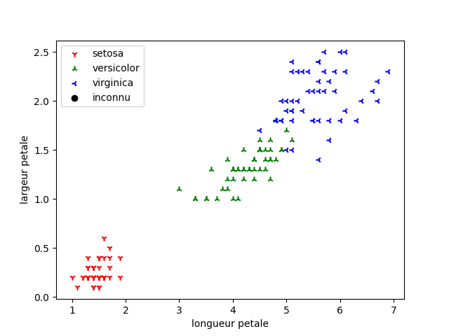

## Question 3

```
print(dataset_p[70])
print(dataset_p[126])
```

```
[4.8, 1.8, 'versicolor']
[4.8, 1.8, 'virginica']
```

Pour un même couple largeur de pétale et longueur de pétale, on a une catégorie différente, ce qui posera un problème à notre algorithme!

## Prédire la classe de fleurs à partir d'un échantillon

## Question 1

On construit et visualise le jeu de données d'entrainement en prenant qu'une fleur sur deux du jeu de données simplifié.

```
plt.clf()
training = [dataset_p[i] for i in range(150) if i%2==0]
illustre_petales(training)
plt.show()
```

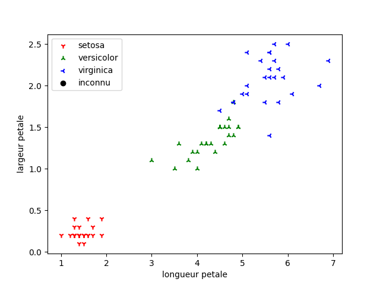

## Question 2

Quelle classe pour la fleur 85 ?

```
def afficher_fleur(i):
    """
    Affiche les données d'entrainement plus la fleur numero i (0<=i<=149, i impair)
    de classe inconnue
    """
    training = [dataset_p[i] for i in range(150) if i%2==0]
    fleur_inconnue = [dataset_p[i][0], dataset_p[i][1], 'inconnu']
    illustre_petales(training + [fleur_inconnue])
    plt.show()
```

```
plt.clf()
afficher_fleur(1)
```

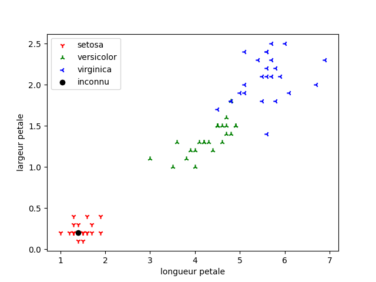

Pour la fleur 1, on devra prédire `setosa`.

```
plt.clf()
afficher_fleur(85)
```

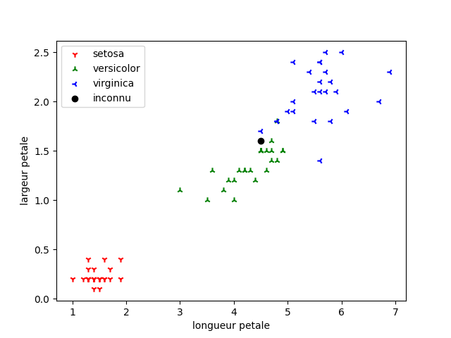

Là c'est un peu plus compliqué, le virginica est le plus proche.

## Question 3 Comprendre et exécuter du code pour calculer une prédiction

Le code est fourni, il ne s'agit ici que de l'utiliser et vérifier les résultats attendus.

Remarque personnelle

Les commentaires du code (et même le code !) du livre sont parfois très maladroits et très mal écrits. Des précisions ou *modifications* ont été apportés au besoin.

### Calcul des k plus proches voisins

```
from math import sqrt

def distance_euclidienne(point1, point2, n):
    """
    Suppose que point1 et point2 sont deux tableaux de longueur au moins n.
    Renvoie la distance euclidienne entre point1 et point2 en prenant seulement en compte leurs coordonnees <= n.
    /!\ Ajout: n est le nombre de coordonnées à prendre en compte pour le calcul de distance car ...
    (on ne veut en general pas prendre la derniere coordonnee qui peut etre une etiquette).
    Complexite: lineaire.

    On rappelle que si
    point1 = [x1, ..., xn]
    point2 = [y1, ..., yn]
    la distance euclidienne est sqrt((y1-x1)**2 + (y2-x2)**2 + ... (yn-xn)**2)
    """
    assert(len(point1) >= n and len(point2) >= n)
    tot = 0
    for i in range(n):
        tot += (point1[i]-point2[i])**2
    return sqrt(tot)
```

```
print(distance_euclidienne([1,0,2], [1,0,2], 2)) # 0.0
print(distance_euclidienne([0,0,0], [1,1,1], 2)) # 1.4142...
```

```
0.0
1.4142135623730951
```

```
def plus_proches_voisins(training, p, k):
    """
    Entree:
    - training: tableau de données d'entrainement contenant m points,
    - p: inconnue, tableau de longueur d,

    - k: entier naturel strictement positif.

    Renvoie le tableau des k plus proches voisins de p parmi training
    pour la distance euclidienne sur les d-1 premieres coordonnes.

    Complexite: O(m * log(m) * d) pour cette version simplifiee.
    Si on calculait toutes les distances avant de trier,
    la complexite deviendrait O(m * log(m) + m * d).
    """
    assert(0 < k and k < len(training))

    def distance(pt):
        """renvoie la distance entre p et pt"""
        assert(len(pt) >= len(p) - 1)
        return distance_euclidienne(pt, p, len(p) - 1)

    training_trie = sorted(training, key=distance) # le critère de tri est fourni par la fonction distance
    return [training_trie[i] for i in range(k)]

def plus_proches_voisins2(training, p, k):
    """
    Entree:
    - training: tableau de données d'entrainement contenant m points,
    - p: inconnue, tableau de longueur d,

    - k: entier naturel strictement positif.

    Renvoie le tableau des k plus proches voisins de p parmi training
    pour la distance euclidienne sur les d-1 premieres coordonnes.

    Complexite: O(m * k * d) pour cette version simplifiee.
    Si on calculait toutes les distances avant de trier,
    la complexite deviendrait O(m * k + m * d).
    """
    assert(0 < k and k < len(training))
    t = training.copy() # une copie superficielle suffit
    for i in range(k):
        # On adapte le tri selection
        # en se limitant a k iterations.
        j_min = i
        for j in range(i+1, len(t)):
            # j_min = indice du minimum parmi t[i],...,t[j-1]
            n = len(p)-1
            if distance_euclidienne(p,t[j],n) < distance_euclidienne(p,t[j_min],n):
                j_min = j
        if j_min != i: # on echange les cases i et j_min
            t[i], t[j_min] = t[j_min], t[i]
    return [t[i] for i in range(k)]
```

```
plus_proches_voisins(training, dataset_p[85], 5)
```

```
[[4.5, 1.7, 'virginica'],
 [4.5, 1.5, 'versicolor'],
 [4.5, 1.5, 'versicolor'],
 [4.5, 1.5, 'versicolor'],
 [4.5, 1.5, 'versicolor']]
```

Résultat

On en déduira que la fleur 85 est du type `versicolor`.

### Prédiction

```
def prediction(training, point, k):
    """
    Entrées:
    - training: tableau de tableaux contenant les d caractéristiques des fleurs
    - point: tableau des d-1 ou d caractéristiques du point inconnu
    - k: entier, correspondant au nombre de voisins du calcul.

    Renvoie:
    la classe la plus courante parmi les k plus proches voisins de point dans training.

    NB: la valeur de la d-ieme coordonnee de point (l'etiquette eventuelle)
    n'est pas utilisee par la fonction.
    """

    # Vérification que le point inconnu a la même structure que ceux de training
    d = len(training[0])
    if len(point) != d: # si necessaire pour harmoniser les dimensions
        point = point + [None] # completer point avec une classe fictive

    # Calcul du tableau des plus proches voisins
    voisins = plus_proches_voisins2(training, point, k)
    print(f'Liste de voisins: {voisins}')
    # Calcul de l'occurence de chaque classe parmi les voisins
    nb_occurrences = {}
    for t in voisins:
        classe = t[d-1]
        nb_occurrences[classe] = nb_occurrences.get(classe, 0) + 1

    # Recherche de la classe la plus représentée
    print(f'nb_occurrences: {nb_occurrences}')
    nb_max = 0
    cle_max = None
    for cle, valeur in nb_occurrences.items():
        if valeur > nb_max:
            cle_max = cle
            nb_max = valeur
    return cle_max
```

Syntaxe

L'utilisation de `.get` (que l'on appelle une *méthode* ... cours de terminale) avec le dictionnaire `nb_occurences` permet de récupérer la valeur associée à la clé `classe`. Si jamais cette clé n'existe pas alors cela renverra une valeur par défaut (ici 0). Cela évite un `KeyError` en cas d'absence de clé.

```
fleur_inconnue = [caracteristique for caracteristique in dataset_petale()[85]]
print("Prédiction k-nn (k=5) pour la fleur 85 :", prediction(dataset_p, fleur_inconnue, 5))
print("La vraie classe de fleur 85 dans le jeu de donnee :",dataset_petale()[85][2])
```

```
Liste de voisins: [[4.5, 1.6, 'versicolor'], [4.5, 1.7, 'virginica'], [4.5, 1.5, 'versicolor'], [4.5, 1.5, 'versicolor'], [4.5, 1.5, 'versicolor']]
nb_occurrences: {'versicolor': 4, 'virginica': 1}
Prédiction k-nn (k=5) pour la fleur 85 : versicolor
La vraie classe de fleur 85 dans le jeu de donnee : versicolor
```